# Lab_01

### Introduction

1. Python is a widely-used general-purpose, high-level programming language. It was initially designed by Guido van Rossum in 1991 and developed by Python Software Foundation
2. Syntax is much simpler to other mid-level languages like C/C++
3. It is an interpreted language
4. Widely used today in fields like Machine Learning and AI due to its simplicity and powerful packages developed by the community

### 1.Installing Python [Version- 3.10]

Windows : [Install python and pip](https://www.tutorialspoint.com/how-to-install-python-in-windows)

Linux :[Install Python](https://www.makeuseof.com/install-python-ubuntu/) [Install Pip](https://www.odoo.com/forum/help-1/how-to-install-pip-in-python-3-on-ubuntu-18-04-167715)

a) **pip** is a python package manager that lets you install powerful python packages developed by open-source developers.  
b) For windows, pip is installed when you install python.  
For linux users, you need to install it seperately  
c) pip install 'package_name'

d) [More on pip](https://www.w3schools.com/python/python_pip.asp)

Install a code-editor, **Sublime Text** or **VS-code** to write your python scripts

### 2.Print Statement

Used to display output in the terminal

```python
print('Welcome to Python Programming Lab')
print('India stands 4th at the Commonwealth Games 2022')

#Multiple items with print
print('MTech','Data','Science')
```

```
Welcome to Python Programming Lab
India stands 4th at the Commonwealth Games 2022
MTech Data Science
```

```python
#WARNING[Python 2 and earlier]
print 'Python Programming'
```

### 3.Data Types

[figure not shown]

**(3.1)** Numeric Types

```python
#Integer
num1 = 100
print(type(num1))

#Float
num2 = 100.1
print(type(num2))
```

```
<class 'int'>
<class 'float'>
```

**Note : No Concept of short, long, double or other modifiers as in C/C++/Java**

**(3.2)** Boolean Types

```python
var1 = True
print(type(var1))

var2 = False
print(type(var2))
```

```
<class 'bool'>
<class 'bool'>
```

**(3.3)** String type  
1. Represents sequence of characters  
2. Enclosed within quotes(either single or double)  
3. If you want a string literal to contain either a single-quote or an apostrophe as part of the string, you can enclose the string literal in double-quote marks

```python
x = 'IITG ranks 7th in NIRF Engineering category'
print(x)

y = "IITG ranks 7th in NIRF Engineering category"
print(y)

z = "It's raining cats and dogs"
print(z)
```

```
IITG ranks 7th in NIRF Engineering category
IITG ranks 7th in NIRF Engineering category
It's raining cats and dogs
```

**NOTE :Unlike C/C++/Java there's no char type here, even a single character is treated as a string**

### 4.Variables

A variable is a name that represents a value stored in the computer’s memory.

**4.1)** You use an assignment statement to create a variable and make it reference a piece of data. An assignment statement is written in the following general format: **variable = expression**  
Example:

```python
dollars = 2.75
print(dollars)

#Reassign variable
dollars = 99.95
print(dollars)
```

```
2.75
99.95
```

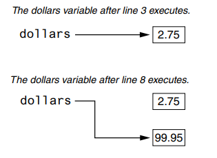

**WARNING!** You cannot use a variable until you have assigned a value to it. An error will occur if you try to perform an operation on a variable, such as printing it, before it has been assigned a value.

```python
temperature = 40
print(temp)
```

```
---------------------------------------------------------------------------
NameError                                 Traceback (most recent call last)
<ipython-input-7-28ce6b64cc4d> in <module>
      1 temperature = 40
----> 2 print(temp)

NameError: name 'temp' is not defined
```

**(4.2)** [Variable Naming Conventions](https://www.w3schools.com/python/gloss_python_variable_names.asp)

```python
1age = 3
print(1age)
```

```
  File "<ipython-input-8-844bd70ed252>", line 1
    1age = 3
       ^
SyntaxError: invalid syntax
```

**(4.3)** Python is a loosely typed language - You don't have to declare variables with data types unlike JAVA or C or C++ etc  
*What a relief !!!*

```python
int a = 10
float b  100.1
```

```python
name = "Lakshya Sen"
age = 20
medal = "gold"
print(name,age,medal)
```

```
Lakshya Sen 20 gold
```

```python
#Benefit of loose type - single variable can hold multiple datatypes
dollars = "Virat Kohli"
print(x)
x = 7
print(x)
```

```
IITG ranks 7th in NIRF Engineering category
7
```

### 5.Reading Input

1.Most of the programs that you will write will need to read input and then perform an operation on that input  
2. **input()** function is used to do this  
3. General Format : **var = input("Input Message")**

**(5.1)** Reading string type data from keyboard

```python
x = input("Enter your name")
print(x)
```

```
Enter your namesoumyadeep
soumyadeep
```

**Note: input() function returns any input as string**

```python
x = input("Enter your age")
print(x)
print(type(x))
```

```
Enter your age25
25
<class 'str'>
```

**(5.2)** Reading numeric data types

```python
#Read integer type data
x = int(input("Enter your age"))
print(x)
print(type(x))

#Read float type data
y = float(input('Enter your cgpa'))
print(y)
print(type(y))
```

```
Enter your age25
25
<class 'int'>
Enter your cgpa8.9
8.9
<class 'float'>
```

### 6.Output Formatting

**(6.1)** Print variables with strings

```python
wickets = int(input("Enter wickets"))

print("Hopefully India doesn't lose by {} wickets remaining this time against Pak".format(wickets))

print(f"Hopefully India doesn't lose by {wickets} wickets remaining this time against Pak")
```

```
Enter wickets10
Hopefully India doesn't lose by 10 wickets remaining this time against Pak
Hopefully India doesn't lose by 10 wickets remaining this time against Pak
```

**(6.2)** Suppressing the print Function’s Ending Newline

The print function normally displays a line of output. For example, the following three statements will produce three lines of output:

```python
print('One')
print('Two')
print('Three')
```

```
One
Two
Three
```

```python
print('One', end=" ")
print('Two', end=' ')
print('Three')
```

```
One Two Three
```

```python
print('One', end=',')
print('Two', end=',')
print('Three')
```

```
One,Two,Three
```

**(6.3)** Formatting Numbers  
**format(variable,specifier)** function is used to do this

```python
x = 5000/12
print(x)
```

```
416.6666666666667
```

```python
x = 5000/12
print(format(x,'.2f'))
print(format(x,'.1f'))
```

```
416.67
416.7
```

```python
print(format(123456, ',d'))
```

```
123,456
```

**Read more about formatting [here](https://www.w3schools.com/python/ref_string_format.asp)**

### 7.Conditional Statements

**(7.1)** If-Else Statement

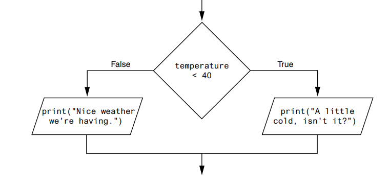

```
if condition:
  statement
  statement
  etc.
else:
  statement
  statement
  etc.
```

```python
temperature = 36

if temperature < 40:
  print("A little cold,isn't it?")
  print("Turn up the heat!!")
else:
  print("Nice weather we're having")
  print("Pass the sunscreen")
```

```
A little cold,isn't it?
Turn up the heat!!
```

**Note :** Indentation is extremely important! Use **TAB** instead of **Space**

**INDENTATION HELL !!!**

```python
number = 5

if number == 1:
 print('One')
else:
  if number == 2:
    print('Two')
  else:
    if number == 3:
      print('Three')
    else:
      print('Unknown')
```

**(7.2)** If-Elif-Else Statement  
When multiple conditions need to be tested

```
if condition_1:
  statement
  statement
  etc.
elif condition_2:
  statement
  statement
  etc.
else:
  statement
  statement
  etc.
```

**Need For If-Elif-Else**

```python
number = 5
if number == 1:
  print("one")
elif number == 2:
  print("two")
elif number == 3:
  print("three")
else:
  print("unknown")
```

**(7.3)** Relational Operators and Boolean Expressions

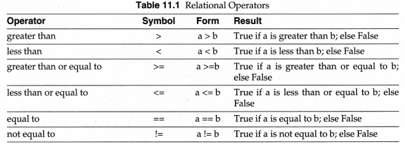

**Read about how strings are compared [here](https://www.geeksforgeeks.org/string-comparison-in-python/)**

**(7.4)** Logical Operators

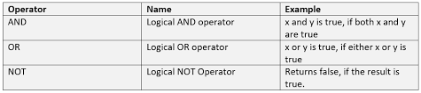

```python
a=34
b=26
if a>1 or b>1:
  print("something")
```

```
something
```

**Short-Circuit Evaluation of Logical Operators**  
1) In case of **and** operator, if the left boolean expression evaluates to **False**, then the entire compound boolean expression evaluated to **FALSE** without the right boolean expression being checked  
2) In case of **or** operator, if the left boolean expression evaluates to **True**, then the entire compound boolean expression evaluated to **True** without the right boolean expression being checked

```python
#Short-circuiting of and operator

num = 10
if num>10 and num%2 == 0:
  print("Ok")
else:
  print("Not OK")
```

```
Not OK
```

```python
#Short-circuiting of or operator

num = 10
if num==10 or num%2 == 0:
  print("Ok")
else:
  print("Not OK")
```

```
Ok
```

### 8.Let's recapitulate what we have learnt so far with this question

*Determine whether a customer qualifies for a loan based on the following criteria*  
*(a)Annual salary is greater than 300000*  
*(b)Minimum work Experience is greater than 3 years*

### 9.Some More Operators with their precedence and associativity

Read [here](https://www.programiz.com/python-programming/precedence-associativity)

### 10.Repetition Structures - Loops

**(10.1)Motivation**

```python
a = 10
print(a)
print(a+1)
print(a+2)
print(a+3)
print(a+4)
#.
#.
#.
print(a+100)
```

[figure not shown]

**We can do better!!**

```python
a = 10
for i in range(100):
  print(a+i)
```

```
10
11
12
13
14
15
16
17
18
19
20
21
22
23
24
25
26
27
28
29
30
31
32
33
34
35
36
37
38
39
40
41
42
43
44
45
46
47
48
49
```

[output cut: 45 more lines]

```
95
96
97
98
99
100
101
102
103
104
105
106
107
108
109
```

[figure not shown]

**Notion of Repetition Structures**

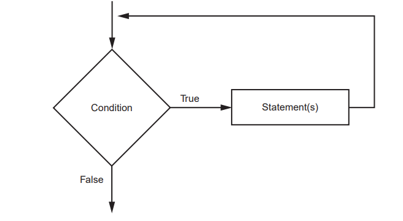

**(10.2) While Loop**  
1.Condition Controlled Loop  
2.Executes the statements inside until the given condition is TRUE

```python
#Initialize a starting condition
life = 10

#Declare the loop
while life > 0:
  print(f'Lives Remaining {life}')
  life = life - 1
```

```
Lives Remaining 10
Lives Remaining 9
Lives Remaining 8
Lives Remaining 7
Lives Remaining 6
Lives Remaining 5
Lives Remaining 4
Lives Remaining 3
Lives Remaining 2
Lives Remaining 1
```

**BEWARE OF INFINITE LOOPS**

```python
#Initialize a starting condition
life = 10

#Declare the loop
while life > 0:
  print(f'Lives Remaining {life}')
```

```python
#Another way to represent infinite loop

while True:
  print('DEAD!!')
```

**(10.3) For Loop**  
1.Count Controlled Loop  
2.Used when the no of times the loop needs to execute is known beforehand

```python
#Execute loop for 5 times
for num in [1,2,3,4,5]:
  print(num)
```

```
1
2
3
4
5
```

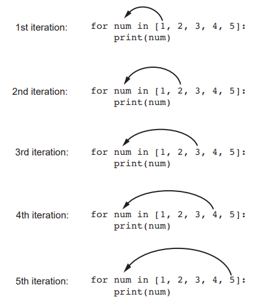

```python
#Use Range function instead of manually typing out the numbers
for num in range(10,0,-1):
  print(num)
```

```
10
9
8
7
6
5
4
3
2
1
```